# Dutch Property Values: A Municipal Analysis

- Show All Code
- Hide All Code
- View Source

Analyzing WOZ Trends Across the Netherlands (2016 - 2024)

Author

Reproducible Research Demo

Published

January 29, 2026

```r
library(data.table)
library(ggplot2)
library(sf)
library(fixest)

# Defines START_YEAR and END_YEAR
source("scripts/constants.R")

# Define major (G4) cities with their gemeente codes
G4_CITIES = data.table::rowwiseDT(
  region=, name=,color=,
  "GM0363", "Amsterdam", "#1b9e77",
  "GM0599", "Rotterdam", "#d95f02",
  "GM0518", "Den Haag", "#7570b3",
  "GM0344", "Utrecht", "#e7298a"
)
```

**WarningNot a real research!**

Don’t mind the narrative but the data is real.

## 1 Introduction

The Dutch housing market has experienced remarkable changes over the past decade. Property values, as measured by the WOZ (*Waardering Onroerende Zaken*) valuations, serve as a key indicator of real estate market dynamics (Vries et al. 2009). These official government valuations are used for property taxation and reflect market conditions across municipalities.

This analysis examines the evolution of property values across Dutch municipalities using data from Statistics Netherlands (CBS). We address the research question:

> **How have property values evolved across Dutch municipalities since 2016, and what spatial patterns emerge?**

Our analysis uses R for data processing, statistical modeling, and visualization, demonstrating Quarto’s capabilities for reproducible research.

## 2 Data

We use the CBS *Kerncijfers Wijken en Buurten* (Key Figures for Neighborhoods and Districts) dataset (Statistics Netherlands (CBS) 2024), which provides annual statistics at the municipality (gemeente) level.

```r
# Load CBS housing data
housing = fread(file.path("data", "processed", "kwb_housing.csv"))
# Keep only from START_YEAR to END_YEAR
housing = housing[year >= START_YEAR & year <= END_YEAR, ]
# Filter to gemeente level with valid WOZ data
housing_municip = housing[region_type == "gemeente" & !is.na(woz), ]

# Summary statistics
n_gem = uniqueN(housing_municip$region)
year_range = range(housing_municip$year)
n_obs = nrow(housing_municip)
```

```r
##| eval: !expr 'START_YEAR != year_range[1] || END_YEAR != year_range[2]'

# Redefine start and end year based on data
start_year_old = START_YEAR
end_year_old = END_YEAR
START_YEAR = max(year_range[1], START_YEAR)
END_YEAR = min(year_range[2], END_YEAR)
if (START_YEAR != start_year_old || END_YEAR != end_year_old) {
  cat(sprintf('WARNING: [Adjusted analysis period to %s-%s based on data availability, you defined [%s, %s].]{style="color:red"}', START_YEAR, END_YEAR, start_year_old, end_year_old))
}
```

The dataset contains 3,236 observations covering 408 municipalities from 2016 to 2024.

```r
summary_by_year = housing_municip[, .(
  Municipalities = uniqueN(region),
  `Mean WOZ (€1000)` = sprintf("%.2f", mean(woz, na.rm = TRUE)),
  `Median WOZ` = sprintf("%.2f", median(woz, na.rm = TRUE)),
  `Min WOZ` = min(woz, na.rm = TRUE),
  `Max WOZ` = max(woz, na.rm = TRUE)
), by = year]

knitr::kable(summary_by_year)
```

Table 1: Data summary by year

| year | Municipalities | Mean WOZ (€1000) | Median WOZ | Min WOZ | Max WOZ |
| --- | --- | --- | --- | --- | --- |
| 2016 | 390 | 222.15 | 219.50 | 122 | 554 |
| 2017 | 380 | 226.96 | 224.00 | 121 | 588 |
| 2018 | 375 | 237.19 | 233.00 | 126 | 637 |
| 2019 | 355 | 258.33 | 250.00 | 131 | 681 |
| 2020 | 355 | 277.07 | 266.00 | 138 | 735 |
| 2021 | 352 | 296.08 | 284.50 | 148 | 775 |
| 2022 | 345 | 324.37 | 314.00 | 167 | 829 |
| 2023 | 342 | 374.01 | 363.00 | 195 | 925 |
| 2024 | 342 | 387.80 | 380.00 | 199 | 900 |

Beyond WOZ values, the dataset includes housing stock composition (see Figure 4 in the Section 8).

## 3 WOZ Trends

### 3.1 Growth Rate Methodology

We calculate the percentage growth in WOZ values for each municipality using the formula:

$$g_i = \frac{\text{WOZ}_{i,t_1} - \text{WOZ}_{i,t_0}}{\text{WOZ}_{i,t_0}} \times 100
\tag{1}$$

where $g_i$ represents the total percentage growth for municipality $i$ over the 2016–2024 period.

### 3.2 Major Cities

Figure 1 shows the evolution of property values in the 4 largest Dutch cities (G4): Amsterdam, Rotterdam, Den Haag, and Utrecht .

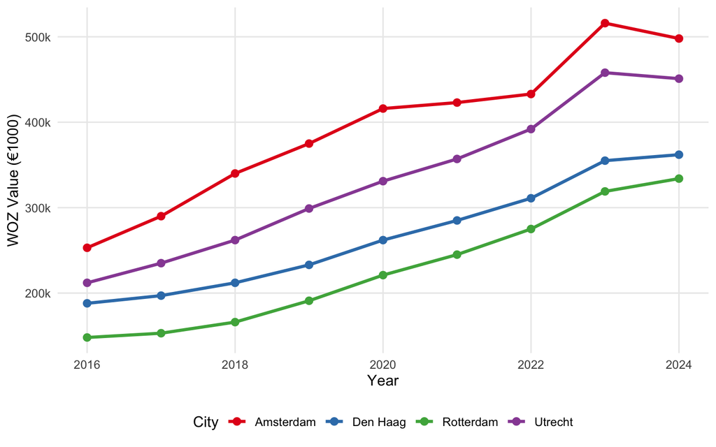

Figure 1: WOZ Value Trends in Major Dutch Cities (2016-2024)

```r
# Filter and join
g4_data = housing_municip[G4_CITIES, on = "region", nomatch = 0]

# Plot
ggplot(g4_data, aes(x = year, y = woz, color = name)) +
  geom_line(linewidth = 1.2) +
  geom_point(size = 2.5) +
  scale_color_brewer(palette = "Set1") +
  scale_x_continuous(breaks = seq(START_YEAR, END_YEAR, 2)) +
  scale_y_continuous(labels = scales::label_number(suffix = "k")) +
  labs(
    x = "Year",
    y = "WOZ Value (€1000)",
    color = "City"
  ) +
  theme_minimal(base_size = 12) +
  theme(
    legend.position = "bottom",
    panel.grid.minor = element_blank()
  )
```

```r
# Identify most expensive city in END_YEAR
expensive_city = g4_data[year == END_YEAR, ][which.max(woz), ]
expensive_city_name = expensive_city[, name]
expensive_city_woz = expensive_city[, woz]
```

Amsterdam shows the highest property values throughout the period, with WOZ values reaching €498k in 2024. The gap between Amsterdam and other cities has remained substantial.

```r
# Calculate growth rates
growth_rates = dcast(
  housing_municip[year %in% c(START_YEAR, END_YEAR), .(region, year, woz)],
  region ~ year,
  value.var = "woz"
)
setnames(growth_rates, as.character(c(START_YEAR, END_YEAR)), c("woz_start", "woz_end"))
growth_rates = growth_rates[!is.na(woz_start) & !is.na(woz_end)]
growth_rates[, growth_pct := (woz_end - woz_start) / woz_start * 100]

# G4 growth rates
g4_growth = growth_rates[G4_CITIES, on = "region", nomatch = 0]
setorder(g4_growth, -growth_pct)
```

The growth rates for the G4 cities between 2016 and 2024 are:

```r
g4_table = g4_growth[, .(
  City = name,
  woz_start,
  woz_end,
  `Growth (%)` = round(growth_pct, 1)
)]
setnames(g4_table, c("woz_start", "woz_end"),
         c(paste("WOZ", START_YEAR), paste("WOZ", END_YEAR)))

knitr::kable(g4_table)
```

Table 2: WOZ Growth in Major Cities (2016-2024)

| City | WOZ 2016 | WOZ 2024 | Growth (%) |
| --- | --- | --- | --- |
| Rotterdam | 148 | 334 | 125.7 |
| Utrecht | 212 | 451 | 112.7 |
| Amsterdam | 253 | 498 | 96.8 |
| Den Haag | 188 | 362 | 92.6 |

## 4 Regression Analysis

To estimate the average annual growth rate across municipalities while controlling for municipal fixed effects, we estimate a panel regression model. Similar approaches using hedonic pricing models have been applied to Dutch real estate appraisals (Guliker, Folmer, and Sinderen 2022). We estimate:

$$\log(\text{WOZ}_{it}) = \alpha + \beta \cdot t + \gamma_i + \varepsilon_{it}
\tag{2}$$

where:

- $\text{WOZ}_{it}$ is the WOZ value for municipality $i$ in year $t$
- $\beta$ captures the average annual growth rate (in log points)
- $\gamma_i$ are municipality fixed effects
- $\varepsilon_{it}$ is the error term

```r
# Prepare panel data
panel = copy(housing_municip)
panel[, `:=`(
  log_woz = log(woz * 1000),
  year_centered = year - START_YEAR  # Center year for interpretation
)]

# Fixed effects regression
fe_model = feols(log_woz ~ year_centered | region, data = panel)

# Extract coefficient
beta = coef(fe_model)["year_centered"]
annual_growth_pct = (exp(beta) - 1) * 100
```

The regression results indicate an average annual growth rate of **7.6%** in WOZ values across Dutch municipalities (see Equation 2). This estimate is based on 3,233 observations across 408 municipalities.

```r
# Summary table
etable(fe_model, se = "cluster", cluster = ~region, tex = knitr::is_latex_output(),
      dict = c(year_centered = sprintf("Year (from %s)", START_YEAR)))
```

Table 3: Panel Regression Results

```
                           fe_model
Dependent Var.:             log_woz

Year (from 2016) 0.0733*** (0.0006)
Fixed-Effects:   ------------------
region                          Yes
________________ __________________
S.E.: Clustered          by: region
Observations                  3,233
R2                          0.97703
Within R2                   0.93980
---
Signif. codes: 0 '***' 0.001 '**' 0.01 '*' 0.05 '.' 0.1 ' ' 1
```

## 5 Spatial Distribution

Figure 2 shows the geographic distribution of WOZ values across Dutch municipalities in 2024.

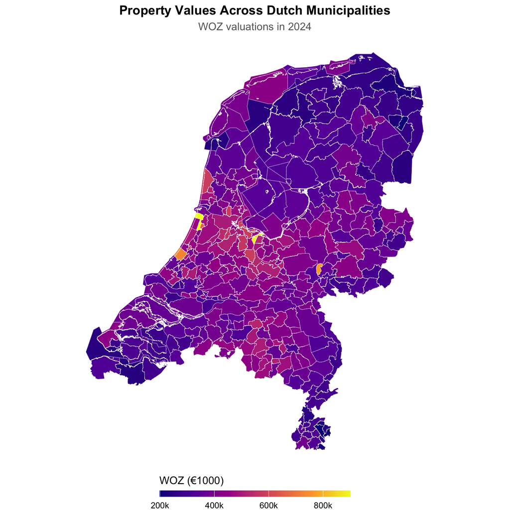

Figure 2: WOZ Values by Municipality (2024)

```r
# Read spatial data
gem_sf = st_read("data/geodata/gemeenten_2024.gpkg", quiet = TRUE)

# Prepare WOZ data for end year
woz_end = housing_municip[year == END_YEAR, .(gemeentecode = region, woz)]

# Join spatial and attribute data
map_data = merge(gem_sf, woz_end, by = "gemeentecode", all.x = TRUE)

# Create choropleth map
ggplot(map_data) +
  geom_sf(aes(fill = woz), color = "white", linewidth = 0.1) +
  scale_fill_viridis_c(
    option = "plasma",
    na.value = "grey80",
    labels = scales::label_number(suffix = "k"),
    guide = guide_colorbar(
      title = "WOZ (€1000)",
      title.position = "top",
      barwidth = 15,
      barheight = 0.5
    )
  ) +
  labs(
    title = "Property Values Across Dutch Municipalities",
    subtitle = paste("WOZ valuations in", END_YEAR)
  ) +
  theme_void(base_size = 12) +
  theme(
    legend.position = "bottom",
    plot.title = element_text(face = "bold", hjust = 0.5),
    plot.subtitle = element_text(hjust = 0.5, color = "grey40")
  )
```

The map Figure 2 reveals clear spatial patterns: the Randstad region (Amsterdam, Utrecht, The Hague) and areas around Haarlem show the highest property values, while peripheral regions in the north and east have lower valuations (Claassens, Koomen, and Rouwendal 2020).

## 6 Compound Annual Growth Rate (CAGR) Analysis

Beyond simple growth rates, we can calculate the Compound Annual Growth Rate [CAGR; Cipra (2010)], which provides a smoothed annual rate of return:

$$\text{CAGR} = \left( \frac{\text{WOZ}_{t_1}}{\text{WOZ}_{t_0}} \right)^{1/n} - 1$$

where $n$ = 8 years.

**Note**

The following figure is embedded from a separate analysis document using Quarto’s [`embed`](https://quarto.org/docs/authoring/notebook-embed.html) shortcode, demonstrating modular workflows:

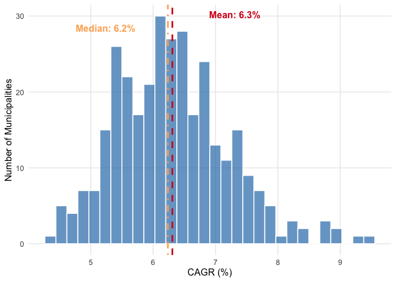

Figure 3: Distribution of Compound Annual Growth Rates

Source: WOZ Summary Statistics

## 7 Conclusion

This analysis of Dutch property values reveals several key findings:

1. **Substantial growth**: WOZ values increased by an average of 7.6% annually between 2016 and 2024
2. **Urban premium**: Major cities, particularly Amsterdam, maintain significantly higher property values (Musterd, Hochstenbach, and Boterman 2020)
3. **Spatial patterns**: Clear geographic clustering with highest values in the Randstad region

These insights have implications for policymakers, urban planners, and real estate stakeholders in understanding market dynamics and guiding future development.

## References

Cipra, Tomas. 2010. *Financial and Insurance Formulas*. Physica-Verlag HD. https://doi.org/10.1007/978-3-7908-2593-0.

Claassens, Jip, Eric Koomen, and Jan Rouwendal. 2020. “Urban Density and Spatial Planning: The Unforeseen Impacts of Dutch Devolution.” Edited by Eda Ustaoglu. *PLOS ONE* 15 (10): e0240738. https://doi.org/10.1371/journal.pone.0240738.

Guliker, Evert, Erwin Folmer, and Marten van Sinderen. 2022. “Spatial Determinants of Real Estate Appraisals in the Netherlands: A Machine Learning Approach.” *ISPRS International Journal of Geo-Information* 11 (2): 125. https://doi.org/10.3390/ijgi11020125.

Musterd, Sako, Cody Hochstenbach, and Willem Boterman. 2020. “Ripples of Structural Economic Transformation: The Changing Social Geographies of Dutch Metropolitan Regions.” *Applied Geography* 116 (March): 102151. https://doi.org/10.1016/j.apgeog.2020.102151.

Statistics Netherlands (CBS). 2024. “Kerncijfers Wijken En Buurten.” https://www.cbs.nl/nl-nl/reeksen/kerncijfers-wijken-en-buurten.

Vries, Paul de, Jan de Haan, Erna van der Wal, and Gust Mariën. 2009. “A House Price Index Based on the SPAR Method.” *Journal of Housing Economics* 18 (3): 214–23. https://doi.org/10.1016/j.jhe.2009.07.002.

## 8 Appendix

### 8.1 Housing Stock Trends

Figure 4 shows trends in housing stock composition for the G4 cities.

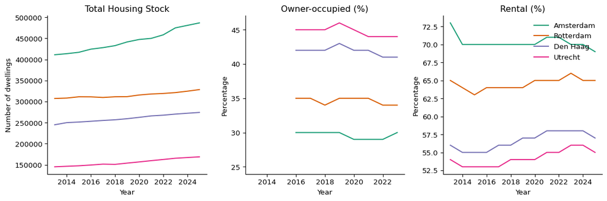

Figure 4: Housing Stock Trends in Major Dutch Cities

Source: Housing Stock Analysis

**Note**

Figure 4 is produced using Python and embedded via Quarto’s `embed` shortcode—demonstrating multi-language workflows.